# Cyclistic_analysis

Silvia

2025-10-09

## Executive Summary

This project analyzes bike trip data from Cyclistic, a bike-share company in Chicago with over 5,800 bikes and 600 docking stations.

**My goal:** Find out how these two groups use bikes differently so the marketing team can create strategies to convert casual riders into annual members.

By organizing and analyzing this data, I identified key patterns in:

- Members take 91% of all rides but casual riders ride 3x longer per trip
- Casual ridership peaks on weekends and in warmer months
- Station usage differs: casual riders use tourist spots, members use business districts

These insights will help Cyclistic design better marketing campaigns to encourage casual riders to become annual members.

## 1. Introduction

Cyclistic is a bike-share company based in Chicago. They launched in 2016 and have grown a lot since then.

##### Now they have:

- A total of 5,824 bikes
- A total of 692 docking stations across Chicago
- Different types of bikes (regular bikes, reclining bikes, hand tricycles, and cargo bikes)

This makes their service accessible to more people, including those who can’t use regular bikes.

## 2. About Cyclistic

##### Cyclistic offers flexible pricing options:

- Single-ride passes
- Full-day passes
- Annual memberships

People who buy single rides or day passes are called **casual riders**. People who buy annual memberships are called **members**.

The company’s finance team discovered that annual members are much more profitable than casual riders. So the marketing director, Lily Moreno, wants to focus on converting casual riders into members instead of trying to attract completely new customers.

This makes sense because casual riders already know about Cyclistic and have used it before. They just need a reason to commit to a membership.

## 3. My Task

I need to answer this question: **How do annual members and casual riders use Cyclistic bikes differently?**

Understanding these differences will help the marketing team create campaigns specifically designed to convince casual riders that a membership is worth it.

## 4. Load and clean data

### The Data I am Using

To answer this question, I have two datasets from Cyclistic (which uses data from Divvy bikes):

- **2019 Q1 data** - All bike trips from January through March 2019
- **2020 Q1 data** - All bike trips from January through March 2020

### These datasets include information about each bike trip:

- When the trip started and ended
- Which stations were used (start and end)
- Whether the rider was a member or casual user
- How long the trip lasted

**Why Q1 data?** I’m using the first quarter (January-March) from two different years because this gives me enough data to find patterns without being too much to handle in RStudio.

**What’s NOT in the data:** For privacy reasons, the data doesn’t include personal information like names, addresses, or payment details. This means I can’t track individual riders or see things like age or gender.

Even with these limitations, this data should give me enough information to spot the key differences between how members and casual riders use the bikes.

### Load libraries

```r
# Data manipulation and analysis
library(tidyverse)   # includes dplyr, ggplot2, tidyr, etc.
library(lubridate)   # for date-time manipulation
```

### Importing Data

```r
# Import 2019 Q1 data
trips_2019_q1 <- read_csv("data/Divvy_Trips_2019_Q1.csv")
# Import 2020 Q1 data
trips_2020_q1 <- read_csv("data/Divvy_Trips_2020_Q1.csv")
# Preview data structure 2019
glimpse(trips_2019_q1)
```

```
## Rows: 365,069
## Columns: 12
## $ trip_id           <dbl> 21742443, 21742444, 21742445, 21742446, 21742447, 21…
## $ start_time        <dttm> 2019-01-01 00:04:37, 2019-01-01 00:08:13, 2019-01-0…
## $ end_time          <dttm> 2019-01-01 00:11:07, 2019-01-01 00:15:34, 2019-01-0…
## $ bikeid            <dbl> 2167, 4386, 1524, 252, 1170, 2437, 2708, 2796, 6205,…
## $ tripduration      <dbl> 390, 441, 829, 1783, 364, 216, 177, 100, 1727, 336, …
## $ from_station_id   <dbl> 199, 44, 15, 123, 173, 98, 98, 211, 150, 268, 299, 2…
## $ from_station_name <chr> "Wabash Ave & Grand Ave", "State St & Randolph St", …
## $ to_station_id     <dbl> 84, 624, 644, 176, 35, 49, 49, 142, 148, 141, 295, 4…
## $ to_station_name   <chr> "Milwaukee Ave & Grand Ave", "Dearborn St & Van Bure…
## $ usertype          <chr> "Subscriber", "Subscriber", "Subscriber", "Subscribe…
## $ gender            <chr> "Male", "Female", "Female", "Male", "Male", "Female"…
## $ birthyear         <dbl> 1989, 1990, 1994, 1993, 1994, 1983, 1984, 1990, 1995…
```

```r
# Preview data structure 2020
glimpse(trips_2020_q1)
```

```
## Rows: 426,887
## Columns: 13
## $ ride_id            <chr> "EACB19130B0CDA4A", "8FED874C809DC021", "789F3C21E4…
## $ rideable_type      <chr> "docked_bike", "docked_bike", "docked_bike", "docke…
## $ started_at         <dttm> 2020-01-21 20:06:59, 2020-01-30 14:22:39, 2020-01-…
## $ ended_at           <dttm> 2020-01-21 20:14:30, 2020-01-30 14:26:22, 2020-01-…
## $ start_station_name <chr> "Western Ave & Leland Ave", "Clark St & Montrose Av…
## $ start_station_id   <dbl> 239, 234, 296, 51, 66, 212, 96, 96, 212, 38, 117, 1…
## $ end_station_name   <chr> "Clark St & Leland Ave", "Southport Ave & Irving Pa…
## $ end_station_id     <dbl> 326, 318, 117, 24, 212, 96, 212, 212, 96, 100, 632,…
## $ start_lat          <dbl> 41.9665, 41.9616, 41.9401, 41.8846, 41.8856, 41.889…
## $ start_lng          <dbl> -87.6884, -87.6660, -87.6455, -87.6319, -87.6418, -…
## $ end_lat            <dbl> 41.9671, 41.9542, 41.9402, 41.8918, 41.8899, 41.884…
## $ end_lng            <dbl> -87.6674, -87.6644, -87.6530, -87.6206, -87.6343, -…
## $ member_casual      <chr> "member", "member", "member", "member", "member", "…
```

## 5. Organizing and cleaning data

### Rename columns

```r
# Rename 2019 columns to match 2020 format
trips_2019_q1 <- trips_2019_q1 %>%
  rename(
    ride_id = trip_id,
    rideable_type = bikeid,
    started_at = start_time,
    ended_at = end_time,
    start_station_name = from_station_name,
    start_station_id = from_station_id,
    end_station_name = to_station_name,
    end_station_id = to_station_id,
    member_casual = usertype
  )

# Check it worked
colnames(trips_2019_q1)
```

```
##  [1] "ride_id"            "started_at"         "ended_at"
##  [4] "rideable_type"      "tripduration"       "start_station_id"
##  [7] "start_station_name" "end_station_id"     "end_station_name"
## [10] "member_casual"      "gender"             "birthyear"
```

```r
colnames(trips_2020_q1)
```

```
##  [1] "ride_id"            "rideable_type"      "started_at"
##  [4] "ended_at"           "start_station_name" "start_station_id"
##  [7] "end_station_name"   "end_station_id"     "start_lat"
## [10] "start_lng"          "end_lat"            "end_lng"
## [13] "member_casual"
```

### Dropping Unnecessary Columns

##### Some columns in the datasets don’t help answer my research question. For example:

- **Latitude/Longitude** - These are useful for mapping, but I’m not creating maps in this analysis
- **Station IDs** - I already have station names, which are easier to read and understand

### To keep my analysis focused and simpler, I decided to keep only the columns I actually need:

- When trips started and ended
- Which stations were used
- Whether the rider was a member or casual user

This makes the data easier to work with and helps me stay focused on answering my main question.

```r
trips_2019_q1 <- trips_2019_q1 %>%
  select(ride_id, started_at, ended_at,
         start_station_name, end_station_name,
         member_casual)

trips_2020_q1 <- trips_2020_q1 %>%
  select(ride_id, started_at, ended_at,
         start_station_name, end_station_name,
         member_casual)
```

### Fix Member Type Labels

```r
# In 2019: "Subscriber" means member, "Customer" means casual
# Change these to match 2020's labels
trips_2019_q1 <- trips_2019_q1 %>%
  mutate(member_casual = recode(member_casual,
                                "Subscriber" = "member",
                                "Customer" = "casual"))
```

### Check Data Types

```r
# Check 2019 data types
str(trips_2019_q1)
```

```
## tibble [365,069 × 6] (S3: tbl_df/tbl/data.frame)
##  $ ride_id           : num [1:365069] 21742443 21742444 21742445 21742446 21742447 ...
##  $ started_at        : POSIXct[1:365069], format: "2019-01-01 00:04:37" "2019-01-01 00:08:13" ...
##  $ ended_at          : POSIXct[1:365069], format: "2019-01-01 00:11:07" "2019-01-01 00:15:34" ...
##  $ start_station_name: chr [1:365069] "Wabash Ave & Grand Ave" "State St & Randolph St" "Racine Ave & 18th St" "California Ave & Milwaukee Ave" ...
##  $ end_station_name  : chr [1:365069] "Milwaukee Ave & Grand Ave" "Dearborn St & Van Buren St (*)" "Western Ave & Fillmore St (*)" "Clark St & Elm St" ...
##  $ member_casual     : chr [1:365069] "member" "member" "member" "member" ...
```

```r
# Check 2020 data types
str(trips_2020_q1)
```

```
## tibble [426,887 × 6] (S3: tbl_df/tbl/data.frame)
##  $ ride_id           : chr [1:426887] "EACB19130B0CDA4A" "8FED874C809DC021" "789F3C21E472CA96" "C9A388DAC6ABF313" ...
##  $ started_at        : POSIXct[1:426887], format: "2020-01-21 20:06:59" "2020-01-30 14:22:39" ...
##  $ ended_at          : POSIXct[1:426887], format: "2020-01-21 20:14:30" "2020-01-30 14:26:22" ...
##  $ start_station_name: chr [1:426887] "Western Ave & Leland Ave" "Clark St & Montrose Ave" "Broadway & Belmont Ave" "Clark St & Randolph St" ...
##  $ end_station_name  : chr [1:426887] "Clark St & Leland Ave" "Southport Ave & Irving Park Rd" "Wilton Ave & Belmont Ave" "Fairbanks Ct & Grand Ave" ...
##  $ member_casual     : chr [1:426887] "member" "member" "member" "member" ...
```

### Matching Data Types

After checking both datasets, I noticed that most columns have matching data types. However, there’s one issue:

- In 2019: ride_id is stored as numeric (numbers)
- In 2020: ride_id is stored as character (text)

Before I can combine the datasets, both need to have the same data type. I’ll convert the 2019 ride_id from numeric to character to match the 2020 format.

```r
# Convert 2019 ride_id from number to text
trips_2019_q1 <- trips_2019_q1 %>%
  mutate(ride_id = as.character(ride_id))
```

### Check Date Formatting

```r
# Check the class/type of the date columns
class(trips_2019_q1$started_at)
```

```
## [1] "POSIXct" "POSIXt"
```

```r
class(trips_2020_q1$started_at)
```

```
## [1] "POSIXct" "POSIXt"
```

```r
# Quick preview
head(trips_2019_q1$started_at)
```

```
## [1] "2019-01-01 00:04:37 UTC" "2019-01-01 00:08:13 UTC"
## [3] "2019-01-01 00:13:23 UTC" "2019-01-01 00:13:45 UTC"
## [5] "2019-01-01 00:14:52 UTC" "2019-01-01 00:15:33 UTC"
```

```r
head(trips_2020_q1$started_at)
```

```
## [1] "2020-01-21 20:06:59 UTC" "2020-01-30 14:22:39 UTC"
## [3] "2020-01-09 19:29:26 UTC" "2020-01-06 16:17:07 UTC"
## [5] "2020-01-30 08:37:16 UTC" "2020-01-10 12:33:05 UTC"
```

### Combine Data

```r
all_trips <- bind_rows(trips_2019_q1, trips_2020_q1)

# Check the combined dataset
paste("Total trips:", nrow(all_trips))
```

```
## [1] "Total trips: 791956"
```

```r
paste("2019 trips:", nrow(trips_2019_q1))
```

```
## [1] "2019 trips: 365069"
```

```r
paste("2020 trips:", nrow(trips_2020_q1))
```

```
## [1] "2020 trips: 426887"
```

```r
# Quick look at the combined data
glimpse(all_trips)
```

```
## Rows: 791,956
## Columns: 6
## $ ride_id            <chr> "21742443", "21742444", "21742445", "21742446", "21…
## $ started_at         <dttm> 2019-01-01 00:04:37, 2019-01-01 00:08:13, 2019-01-…
## $ ended_at           <dttm> 2019-01-01 00:11:07, 2019-01-01 00:15:34, 2019-01-…
## $ start_station_name <chr> "Wabash Ave & Grand Ave", "State St & Randolph St",…
## $ end_station_name   <chr> "Milwaukee Ave & Grand Ave", "Dearborn St & Van Bur…
## $ member_casual      <chr> "member", "member", "member", "member", "member", "…
```

### Check for Missing/Null Values (NAs)

```r
# Count missing values in each column
colSums(is.na(all_trips))
```

```
##            ride_id         started_at           ended_at start_station_name
##                  0                  0                  0                  0
##   end_station_name      member_casual
##                  1                  0
```

```r
# Or see the total missing values
sum(is.na(all_trips))
```

```
## [1] 1
```

#### Removing missing value to be cleaner(One value will not affect thi analysis).

```r
all_trips <- all_trips %>%
  filter(!is.na(end_station_name))
```

#### Checking duplicates

```r
# Count how many duplicate ride_ids exist
sum(duplicated(all_trips$ride_id))
```

```
## [1] 0
```

```r
# See which ride_ids are duplicated (if any)
all_trips %>%
  filter(duplicated(ride_id) | duplicated(ride_id, fromLast = TRUE)) %>%
  arrange(ride_id)
```

```
## # A tibble: 0 × 6
## # ℹ 6 variables: ride_id <chr>, started_at <dttm>, ended_at <dttm>,
## #   start_station_name <chr>, end_station_name <chr>, member_casual <chr>
```

### Adding columns

Adding the columns needed for analysis:

- *ride_length_mins* - How long each ride lasted (in minutes)
- *day_of_week* - Which day (Monday, Tuesday, etc.)
- *hour* - What time of day (0-23)

```r
# Add new columns
all_trips <- all_trips %>%
  mutate(
    # Calculate ride length in minutes
    ride_length_mins = as.numeric(difftime(ended_at, started_at, units = "mins")),

    # Get day of the week
    day_of_week = wday(started_at, label = TRUE),

    # Get hour of day (0-23)
    hour = hour(started_at),

    # Get month
    month = month(started_at, label = TRUE)
  )

# Check it worked
glimpse(all_trips)
```

```
## Rows: 791,955
## Columns: 10
## $ ride_id            <chr> "21742443", "21742444", "21742445", "21742446", "21…
## $ started_at         <dttm> 2019-01-01 00:04:37, 2019-01-01 00:08:13, 2019-01-…
## $ ended_at           <dttm> 2019-01-01 00:11:07, 2019-01-01 00:15:34, 2019-01-…
## $ start_station_name <chr> "Wabash Ave & Grand Ave", "State St & Randolph St",…
## $ end_station_name   <chr> "Milwaukee Ave & Grand Ave", "Dearborn St & Van Bur…
## $ member_casual      <chr> "member", "member", "member", "member", "member", "…
## $ ride_length_mins   <dbl> 6.500000, 7.350000, 13.816667, 29.716667, 6.066667,…
## $ day_of_week        <ord> Tue, Tue, Tue, Tue, Tue, Tue, Tue, Tue, Tue, Tue, T…
## $ hour               <int> 0, 0, 0, 0, 0, 0, 0, 0, 0, 0, 0, 0, 0, 0, 0, 0, 0, …
## $ month              <ord> Jan, Jan, Jan, Jan, Jan, Jan, Jan, Jan, Jan, Jan, J…
```

```r
head(all_trips)
```

```
## # A tibble: 6 × 10
##   ride_id  started_at          ended_at            start_station_name
##   <chr>    <dttm>              <dttm>              <chr>
## 1 21742443 2019-01-01 00:04:37 2019-01-01 00:11:07 Wabash Ave & Grand Ave
## 2 21742444 2019-01-01 00:08:13 2019-01-01 00:15:34 State St & Randolph St
## 3 21742445 2019-01-01 00:13:23 2019-01-01 00:27:12 Racine Ave & 18th St
## 4 21742446 2019-01-01 00:13:45 2019-01-01 00:43:28 California Ave & Milwaukee A…
## 5 21742447 2019-01-01 00:14:52 2019-01-01 00:20:56 Mies van der Rohe Way & Chic…
## 6 21742448 2019-01-01 00:15:33 2019-01-01 00:19:09 LaSalle St & Washington St
## # ℹ 6 more variables: end_station_name <chr>, member_casual <chr>,
## #   ride_length_mins <dbl>, day_of_week <ord>, hour <int>, month <ord>
```

### Removing Bad Data

```r
# Check the range of ride lengths before cleaning
paste("Total trips:", nrow(all_trips))
```

```
## [1] "Total trips: 791955"
```

```r
paste("Min ride length:", min(all_trips$ride_length_mins), "mins")
```

```
## [1] "Min ride length: -9.2 mins"
```

```r
paste("Max ride length:", max(all_trips$ride_length_mins), "mins")
```

```
## [1] "Max ride length: 177200.366666667 mins"
```

```r
# Remove unrealistic rides
all_trips_clean <- all_trips %>%
  filter(
    ride_length_mins >= 1,       # At least 1 minute
    ride_length_mins < 1440       # Less than 24 hours (1440 mins)
  )

# Check after cleaning
paste("Total trips:", nrow(all_trips_clean))
```

```
## [1] "Total trips: 783803"
```

```r
paste("Removed:", nrow(all_trips) - nrow(all_trips_clean), "trips")
```

```
## [1] "Removed: 8152 trips"
```

```r
paste("Min ride length:", min(all_trips_clean$ride_length_mins), "mins")
```

```
## [1] "Min ride length: 1 mins"
```

```r
paste("Max ride length:", max(all_trips_clean$ride_length_mins), "mins")
```

```
## [1] "Max ride length: 1435.91666666667 mins"
```

## 6. Analize data

### **Step 1: Basic Comparison - Members vs Casual**

```r
# Total rides by user type
all_trips_clean %>%
  group_by(member_casual) %>%
  summarise(
    total_rides = n(),
    percentage = round(n() / nrow(all_trips_clean) * 100, 1)
  )
```

```
## # A tibble: 2 × 3
##   member_casual total_rides percentage
##   <chr>               <int>      <dbl>
## 1 casual              67397        8.6
## 2 member             716406       91.4
```

```r
# Average ride length by user type
all_trips_clean %>%
  group_by(member_casual) %>%
  summarise(
    avg_ride_length = round(mean(ride_length_mins), 2),
    median_ride_length = round(median(ride_length_mins), 2),
    max_ride_length = round(max(ride_length_mins), 2),
    min_ride_length = round(min(ride_length_mins), 2)
  )
```

```
## # A tibble: 2 × 5
##   member_casual avg_ride_length median_ride_length max_ride_length
##   <chr>                   <dbl>              <dbl>           <dbl>
## 1 casual                   38.5               23.2           1436.
## 2 member                   11.5                8.5           1433.
## # ℹ 1 more variable: min_ride_length <dbl>
```

### **Step 2: Day of Week Analysis**

```r
# Rides by day of week
day_summary <- all_trips_clean %>%
  group_by(member_casual, day_of_week) %>%
  summarise(
    number_of_rides = n(),
    avg_ride_length = round(mean(ride_length_mins), 2)
  ) %>%
  arrange(member_casual, day_of_week)
# View the results
day_summary
```

```
## # A tibble: 14 × 4
## # Groups:   member_casual [2]
##    member_casual day_of_week number_of_rides avg_ride_length
##    <chr>         <ord>                 <int>           <dbl>
##  1 casual        Sun                   18512            41
##  2 casual        Mon                    5558            34.5
##  3 casual        Tue                    7266            35.7
##  4 casual        Wed                    7623            41.3
##  5 casual        Thu                    7085            35.4
##  6 casual        Fri                    7954            37.2
##  7 casual        Sat                   13399            39.0
##  8 member        Sun                   59697            13.0
##  9 member        Mon                  109855            11.2
## 10 member        Tue                  127363            11.4
## 11 member        Wed                  121302            11.2
## 12 member        Thu                  124568            11.1
## 13 member        Fri                  114588            11.2
## 14 member        Sat                   59033            12.5
```

**What I Found:**

### **Step 3: Monthly Trends**

```r
# Rides by month
month_summary <- all_trips_clean %>%
  group_by(member_casual, month) %>%
  summarise(
    number_of_rides = n(),
    avg_ride_length = round(mean(ride_length_mins), 2)
  ) %>%
  arrange(member_casual, month)
# View the results
month_summary
```

```
## # A tibble: 6 × 4
## # Groups:   member_casual [2]
##   member_casual month number_of_rides avg_ride_length
##   <chr>         <ord>           <int>           <dbl>
## 1 casual        Jan             12269            36.3
## 2 casual        Feb             14833            37.6
## 3 casual        Mar             40295            39.5
## 4 member        Jan            233476            11.1
## 5 member        Feb            218915            11.2
## 6 member        Mar            264015            12.0
```

**What to look for:** - Which months are busiest for casual riders? March is the busiest month. As the temperature warms up, more people want to ride bikes for sightseeing and outdoor activities. - Do members ride consistently year-round? Yes, members show consistent ridership throughout Q1 with only small differences between months. This suggests they rely on bikes regardless of weather. - When should you launch marketing campaigns? Launch campaigns in early spring (February/March) to capture casual riders as weather improves and ridership increases.

### **Step 4: Popular Stations**

```r
# Top 10 start stations for casual riders
cat("Top 10 stations for CASUAL riders:\n")
```

```
## Top 10 stations for CASUAL riders:
```

```r
all_trips_clean %>%
  filter(member_casual == "casual") %>%
  group_by(start_station_name) %>%
  summarise(rides = n()) %>%
  arrange(desc(rides)) %>%
  head(10)
```

```
## # A tibble: 10 × 2
##    start_station_name           rides
##    <chr>                        <int>
##  1 Streeter Dr & Grand Ave       2733
##  2 Lake Shore Dr & Monroe St     2726
##  3 Shedd Aquarium                1828
##  4 Millennium Park               1401
##  5 Michigan Ave & Oak St         1015
##  6 Michigan Ave & Washington St   834
##  7 Dusable Harbor                 829
##  8 Adler Planetarium              824
##  9 Theater on the Lake            792
## 10 Lake Shore Dr & North Blvd     603
```

```r
# Top 10 start stations for members
cat("Top 10 stations for MEMBERS:\n")
```

```
## Top 10 stations for MEMBERS:
```

```r
all_trips_clean %>%
  filter(member_casual == "member") %>%
  group_by(start_station_name) %>%
  summarise(rides = n()) %>%
  arrange(desc(rides)) %>%
  head(10)
```

```
## # A tibble: 10 × 2
##    start_station_name           rides
##    <chr>                        <int>
##  1 Canal St & Adams St          13752
##  2 Clinton St & Washington Blvd 13392
##  3 Clinton St & Madison St      12836
##  4 Kingsbury St & Kinzie St      8685
##  5 Columbus Dr & Randolph St     8467
##  6 Canal St & Madison St         7860
##  7 Franklin St & Monroe St       6971
##  8 Michigan Ave & Washington St  6671
##  9 Larrabee St & Kingsbury St    6442
## 10 Clinton St & Lake St          6418
```

**What to look for:**

-Are casual rider stations near tourist spots? Yes! Casual riders start their trips at stations located in tourist areas and popular attractions.

-Are member stations near offices/transit? Yes! Members primarily use stations near business districts and public transportation hubs.

-What this means: Different locations confirm different user types. Casual riders are tourists or leisure users exploring the city, while members are local commuters using bikes for work and daily travel.

## 7. Data Visualizations

### Chart 1: Total Rides - Members vs Casual

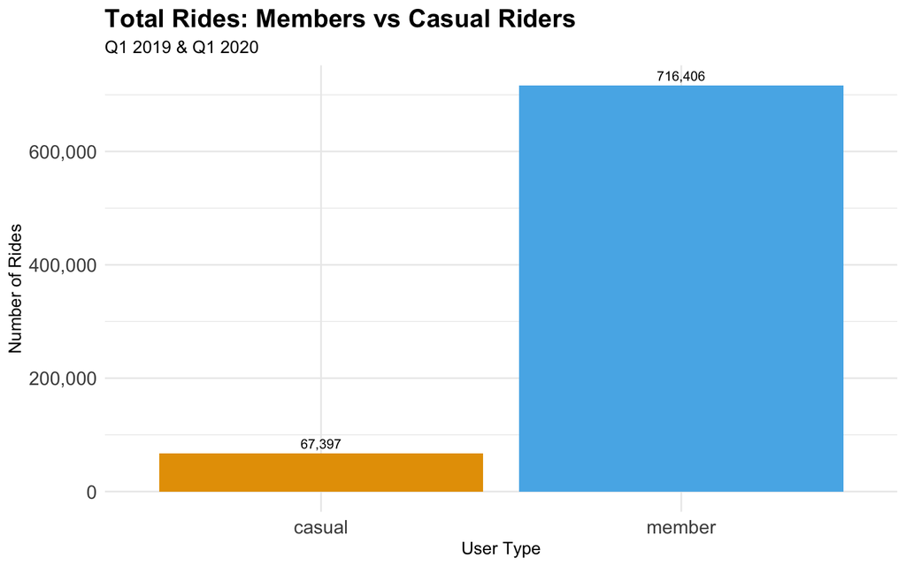

```r
# Create a simple bar chart comparing total rides
all_trips_clean %>%
  group_by(member_casual) %>%
  summarise(total_rides = n()) %>%
  ggplot(aes(x = member_casual, y = total_rides, fill = member_casual)) +
  geom_col() +
  geom_text(aes(label = scales::comma(total_rides)),
            vjust = -0.5, size = 3) +
  scale_fill_manual(values = c("casual" = "#E69F00", "member" = "#56B4E9")) +
  scale_y_continuous(labels = scales::comma) +
  labs(
    title = "Total Rides: Members vs Casual Riders",
    subtitle = "Q1 2019 & Q1 2020",
    x = "User Type",
    y = "Number of Rides"
  ) +
  theme_minimal() +
  theme(
    legend.position = "none",
    plot.title = element_text(size = 16, face = "bold"),
    axis.text = element_text(size = 12)
  )
```

### Chart 2: Average duration comparison

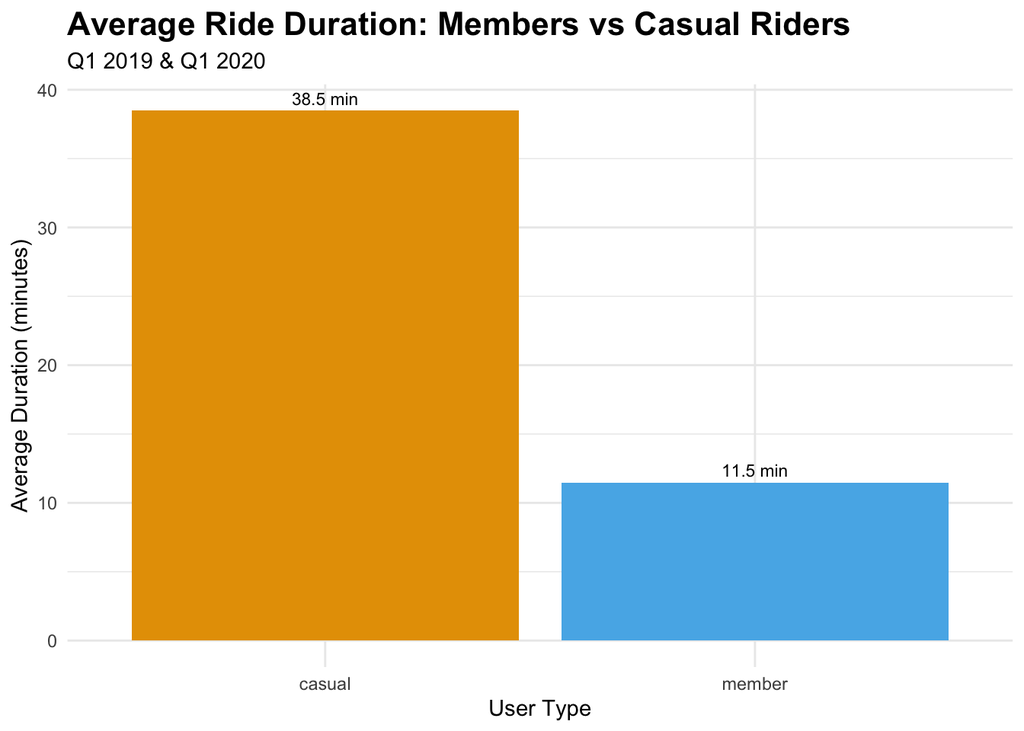

```r
all_trips_clean %>%
  group_by(member_casual) %>%
  summarise(avg_duration = mean(ride_length_mins)) %>%
  ggplot(aes(x = member_casual, y = avg_duration, fill = member_casual)) +
  geom_col() +
  geom_text(aes(label = paste0(round(avg_duration, 1), " min")),
            vjust = -0.5, size = 3) +
  scale_fill_manual(values = c("casual" = "#E69F00", "member" = "#56B4E9")) +
  labs(
    title = "Average Ride Duration: Members vs Casual Riders",
    subtitle = "Q1 2019 & Q1 2020",
    x = "User Type",
    y = "Average Duration (minutes)"
  ) +
  theme_minimal() +
  theme(legend.position = "none",
        plot.title = element_text(size = 16, face = "bold"))
```

### Chart 3: Rides by day of week

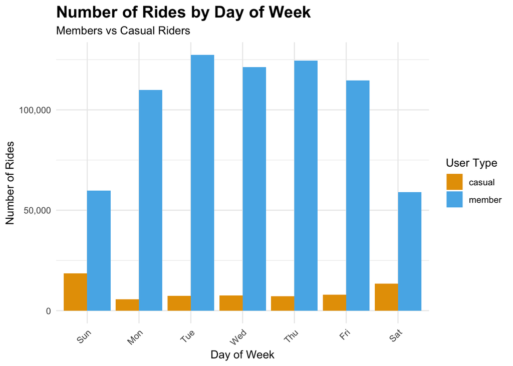

```r
all_trips_clean %>%
  group_by(member_casual, day_of_week) %>%
  summarise(number_of_rides = n()) %>%
  ggplot(aes(x = day_of_week, y = number_of_rides, fill = member_casual)) +
  geom_col(position = "dodge") +
  scale_y_continuous(labels = scales::comma) +
  scale_fill_manual(values = c("casual" = "#E69F00", "member" = "#56B4E9")) +
  labs(
    title = "Number of Rides by Day of Week",
    subtitle = "Members vs Casual Riders",
    x = "Day of Week",
    y = "Number of Rides",
    fill = "User Type"
  ) +
  theme_minimal() +
  theme(plot.title = element_text(size = 16, face = "bold"),
        axis.text.x = element_text(angle = 45, hjust = 1))
```

### Chart 4: Average duration by day

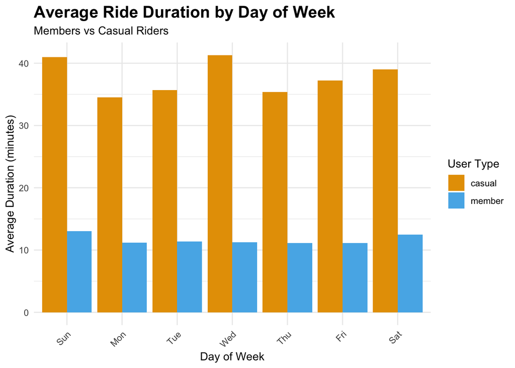

```r
all_trips_clean %>%
  group_by(member_casual, day_of_week) %>%
  summarise(avg_duration = mean(ride_length_mins)) %>%
  ggplot(aes(x = day_of_week, y = avg_duration, fill = member_casual)) +
  geom_col(position = "dodge") +
  scale_fill_manual(values = c("casual" = "#E69F00", "member" = "#56B4E9")) +
  labs(
    title = "Average Ride Duration by Day of Week",
    subtitle = "Members vs Casual Riders",
    x = "Day of Week",
    y = "Average Duration (minutes)",
    fill = "User Type"
  ) +
  theme_minimal() +
  theme(plot.title = element_text(size = 16, face = "bold"),
        axis.text.x = element_text(angle = 45, hjust = 1))
```

### Chart 5: Rides by hour

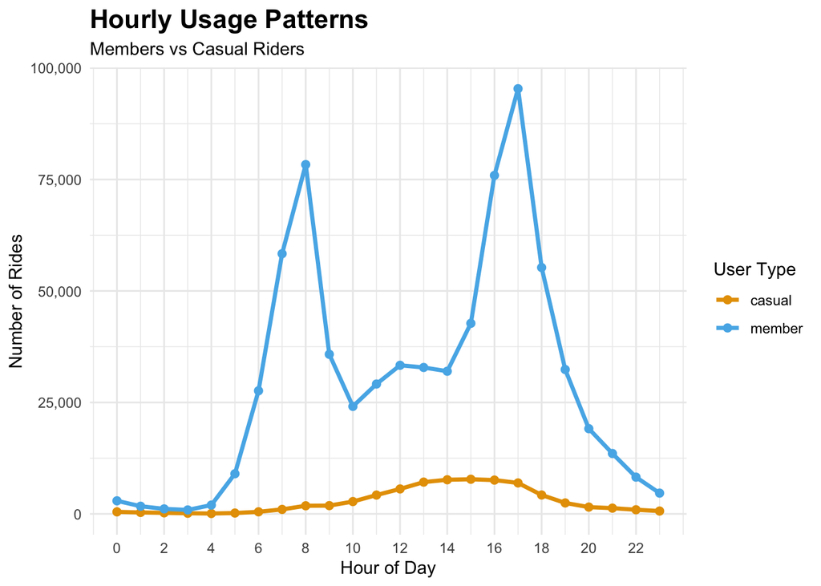

```r
all_trips_clean %>%
  group_by(member_casual, hour) %>%
  summarise(number_of_rides = n()) %>%
  ggplot(aes(x = hour, y = number_of_rides, color = member_casual, group = member_casual)) +
  geom_line(size = 1.2) +
  geom_point(size = 2) +
  scale_y_continuous(labels = scales::comma) +
  scale_x_continuous(breaks = seq(0, 23, 2)) +
  scale_color_manual(values = c("casual" = "#E69F00", "member" = "#56B4E9")) +
  labs(
    title = "Hourly Usage Patterns",
    subtitle = "Members vs Casual Riders",
    x = "Hour of Day",
    y = "Number of Rides",
    color = "User Type"
  ) +
  theme_minimal() +
  theme(plot.title = element_text(size = 16, face = "bold"))
```

### Chart 6: Monthly rides

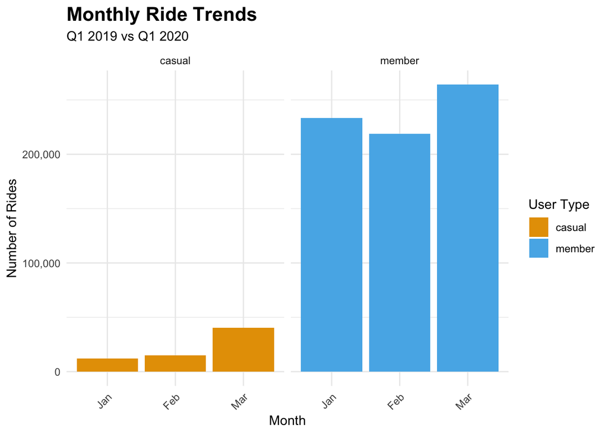

```r
all_trips_clean %>%
  group_by(member_casual, month) %>%
  summarise(number_of_rides = n()) %>%
  ggplot(aes(x = month, y = number_of_rides, fill = member_casual)) +
  geom_col(position = "dodge") +
  scale_y_continuous(labels = scales::comma) +
  scale_fill_manual(values = c("casual" = "#E69F00", "member" = "#56B4E9")) +
  facet_wrap(~ member_casual) +
  labs(
    title = "Monthly Ride Trends",
    subtitle = "Q1 2019 vs Q1 2020",
    x = "Month",
    y = "Number of Rides",
    fill = "User Type"
  ) +
  theme_minimal() +
  theme(plot.title = element_text(size = 16, face = "bold"),
        axis.text.x = element_text(angle = 45, hjust = 1))
```

## 8. Key Findings

#### Based on the analysys we can say that the key differences between members and casual riders:

**Ride Frequency:**

- Members account for 91.4% of all rides (716,406 rides) while casual riders only 8.6% (67,397 rides)
- Members take approximately 11 times more rides than casual users

**Ride Duration:**

- Casual riders take significantly longer rides, averaging 38.5 minutes per trip
- Members average only 11.5 minutes per trip
- Casual riders ride 3.3 times longer than members, suggesting leisure vs. commute purposes

**Day of Week Patterns:**

- Members show clear morning and evening commute peaks (8 AM and 5-6 PM)
- Casual riders have more evenly distributed usage throughout the day
- This further confirms different usage purposes

**Seasonal Patterns:** - Casual ridership triples from January to March (12,269 → 40,295 rides) as weather warms - Members stay relatively consistent across all three months - Casual riders are highly weather-dependent; members ride regardless of conditions

## 9. Recommendations

#### Based on the analysis, here top four recomendations for converting casual riders into annual members:

- *Weekend Membership Promotion:* Our data shows casual riders peak on weekends (18,512 Sunday rides vs. 5,558 Monday rides). Create a ‘Weekend Warrior’ membership tier targeting these leisure riders. Emphasize unlimited weekend rides for one flat rate since casual riders already ride 3.3x longer than members.
- *Members Incentive Program:* Develop marketing materials emphasizing cost savings for daily commuters. Show casual riders how much they could save with an annual membership if they commute just 2-3 days per week.
- *Seasonal Conversion Campaign:* Launch membership campaigns at the start of peak seasons (spring/summer) when casual ridership increases. Offer discounted annual memberships to riders during their first few casual trips.
- *Family discounts:* Create a campaign to share that the company support families, make discount for second or third members in the family.

## 10. Conclusion

#### This analysis successfully identified distinct usage patterns between Cyclistic annual members and casual riders. The insights gained provide a clear foundation for targeted marketing strategies aimed at converting casual riders into profitable annual members.

*Next Steps*

- Expand Analysis: Analyze a full year of data to understand seasonal variations
- Geographic Analysis: Identify which stations have the highest casual rider traffic for targeted campaigns
- A/B Testing: Test different marketing messages with casual riders
- User Surveys: Conduct surveys to understand barriers to membership conversion